# CS4423 Assignment 1: Outline Solutions

### Usual list of Python modules

```python
import networkx as nx
import numpy as np
import matplotlib.pyplot as plt
opts = { "with_labels": True, "node_color": 'y' } # show labels; yellow noodes
```

## Q1: Bipartite Graphs

### Define and draw the following graph

Let $G_1$ be the graph on the nodes $\{0, 1, 2, 3, 4, 5, 6\}$ with edges $0-1$, $1-2$, $1-4$, $1-6$, $2-3$, $3-4$, $4-5$, $5-6$.  
Define this graph in `networkx` and draw it.

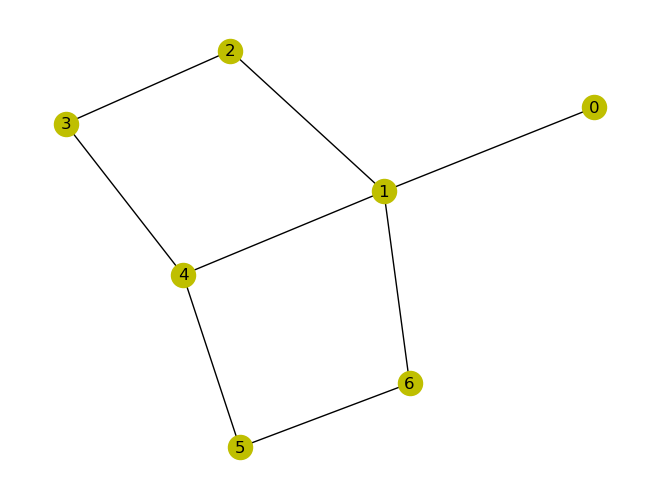

```python
G1 = nx.Graph(["01","12","14", "23",  "34","45","56","61"])
nx.draw(G1, **opts)
```

### Determine if $G_1$ is bipartite.

If $G_1$ is bipartite, draw it in `networkx` with a two-colouring of the nodes. If not, explain why it is not bipartite.

```
['0', '1', '2', '4', '3', '5', '6']
```

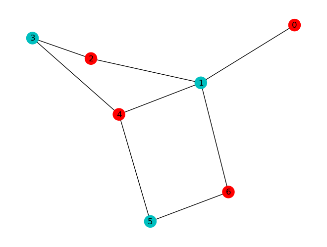

```python
print(G1.nodes()) # useful for checking the node ordering
colouring = ['r','c','r','r','c','c','r']
nx.draw(G1, node_color=colouring, with_labels=True) # this is  a two-colouring, so G1 is bipartite.
```

## Q2: A Network of friends

### Define a graph in `networkx` that represents this scenario.

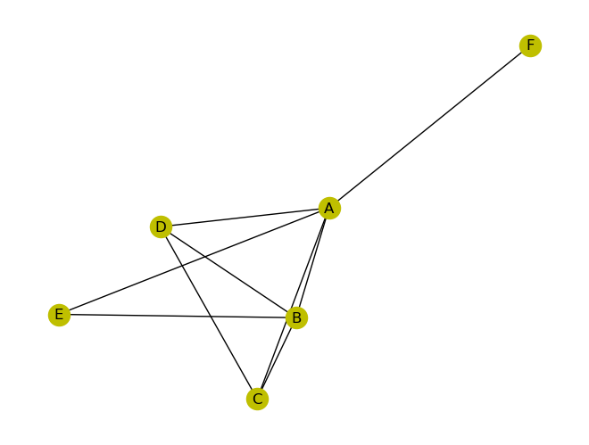

```python
G2 = nx.Graph()
G2.add_nodes_from("ABCDEF")
G2.add_edges_from(["AB","AC","AD","AE","AF"]) # friends of A
G2.add_edges_from(["BC","BD","BE"]) # other friends of A
G2.add_edges_from(["CD"]) # other friends of A

nx.draw(G2, **opts)
```

### Verify that the graph has the correct properties by displaying the diagonal of the square of the graphs adjacency matrix.

*Hint*: `np.diag(X)` returns the entries on the main diagonal of $X$.

```python
A2 = nx.adjacency_matrix(G2).toarray()
print( np.diag(A2@A2))
```

```
[5 4 3 3 2 1]
```

## Q3: Isomorphic graphs

In `networkx` we can check if two (smallish) graphs, $G$ and $H$, are **isomorphic** by using the `nx.is_isomorphic()` function: `nx.is_isomorphic(G,H)` evaluates as `True` if they are isomorphic.

### Self-complementary cycle graph

Use `networkx` to check which of the cycle graphs $C_3$, $C_4$, $\dots$, $C_{10}$ are isomorphic to its own complement.  
Notes:

- You can use the constructor `nx.cycle_graph(n)` to make $C_n$
- You can use the method `nx.complement(G)` to make construct the complement of the graph $G$.

```python
for n in range(3,11):
    G3 = nx.cycle_graph(n)
    Answer = nx.is_isomorphic(G3, nx.complement(G3))
    if (Answer == True):
        print(f"C{n} is isomorphic to its complement")
    else:
        print(f"C{n} is NOT isomorphic to its complement")
```

```
C3 is NOT isomorphic to its complement
C4 is NOT isomorphic to its complement
C5 is isomorphic to its complement
C6 is NOT isomorphic to its complement
C7 is NOT isomorphic to its complement
C8 is NOT isomorphic to its complement
C9 is NOT isomorphic to its complement
C10 is NOT isomorphic to its complement
```

### Graphs that are isomorphic to their line graphs.

Use `networkx` to check that all cycle graphs $C_3$, $C_4$, $\dots$, $C_{10}$ are isomorphic to their line graphs.

You can use the `nx.line_graph()` function.

```python
for n in range(3,11):
    G3 = nx.cycle_graph(n)
    H3 = nx.line_graph(G3)
    Answer = nx.is_isomorphic(G3, H3)
    if (Answer == True):
        print(f"C{n} is isomorphic to its line graph")
    else:
        print(f"C{n} is NOT isomorphic to its line graph")
```

```
C3 is isomorphic to its line graph
C4 is isomorphic to its line graph
C5 is isomorphic to its line graph
C6 is isomorphic to its line graph
C7 is isomorphic to its line graph
C8 is isomorphic to its line graph
C9 is isomorphic to its line graph
C10 is isomorphic to its line graph
```

## Q4: Bipartite Graphs

Consider the following affiliation network, $G_4$, with $8$ people labelled $a$ to $h$, and five foci ("focal points" of interaction) labelled $1$ to $5$:

[figure not shown]

1. Create this graph in `networkx` and draw it with a two-colouring.
2. Compute the adjacency matrix of $G$.
3. Draw the projection on (just) the people, in which two people are joined by an edge if they have a common focus. (You can do this by hand, or in `networkx`.)

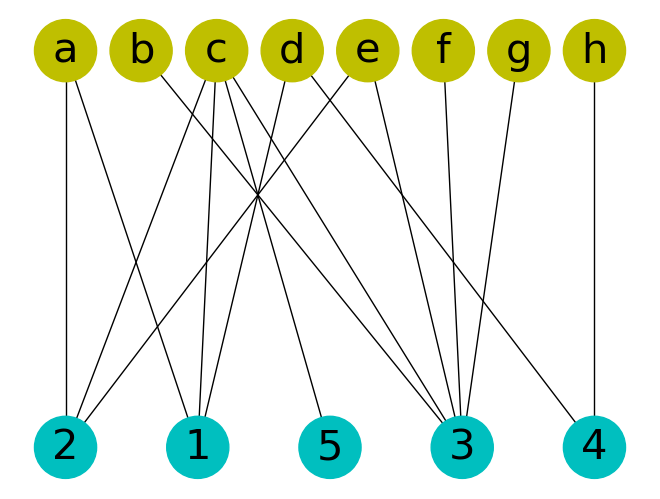

```python
# 1. Making and drawing the grap
G4 = nx.Graph()
G4.add_nodes_from("12345abcdefgh")
G4.add_edges_from(["a1", "a2", "b3", "c1", "c2", "c3", "c5", "d1","d4", "e2", "e3", "f3", "g3", "h4"])
top, bottom = nx.bipartite.sets(G4)
if 'a' in top:
    Actors = top; Foci = bottom;
else:
    Actors = bottom; Foci = top;
colouring = 5*['c']+8*['y']
positions = nx.bipartite_layout(G4, Foci, align='horizontal') # compute the positions
nx.draw(G4, with_labels=True, node_color=colouring, pos=positions, font_size=30, node_size=2000)
```

```python
# 2. Adjacency matrix
A4 = nx.adjacency_matrix(G4).toarray()
print(A4)
```

```
[[0 0 0 0 0 1 0 1 1 0 0 0 0]
 [0 0 0 0 0 1 0 1 0 1 0 0 0]
 [0 0 0 0 0 0 1 1 0 1 1 1 0]
 [0 0 0 0 0 0 0 0 1 0 0 0 1]
 [0 0 0 0 0 0 0 1 0 0 0 0 0]
 [1 1 0 0 0 0 0 0 0 0 0 0 0]
 [0 0 1 0 0 0 0 0 0 0 0 0 0]
 [1 1 1 0 1 0 0 0 0 0 0 0 0]
 [1 0 0 1 0 0 0 0 0 0 0 0 0]
 [0 1 1 0 0 0 0 0 0 0 0 0 0]
 [0 0 1 0 0 0 0 0 0 0 0 0 0]
 [0 0 1 0 0 0 0 0 0 0 0 0 0]
 [0 0 0 1 0 0 0 0 0 0 0 0 0]]
```

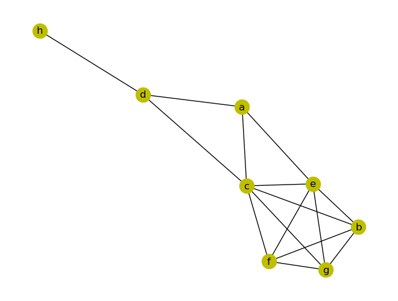

```python
# 3. Draw the projection
GX1 = nx.projected_graph(G4, Actors)
nx.draw(GX1, **opts)
```

## Q5: Directed Graphs

So far in CS4423 we have only considered **undirected graphs**. That is, the edge $a-b$ is the same as the edge $b-a$.

Now I want you to think about *directed graphs* (also called *digraphs*): where the edge $a \to b$ is not the same as the edge $b \to a$. One can think of such edges as "one way streets": an edge that can be used to get from $a$ to $b$ can't be used to get from $b$ to $a$.

There are numerous differences between directed and undirected graphs, including:

- When you draw a digraph you add arrows to edges to indicate its direction.
- If there is an edge $u \to v$ and $v \to u$, this can be represented by either having two edges between these nodes (with arrows in opposite directions), or by adding two arrows to a single edge.
- The adjacency matrix is not necessarily symmetric.
- The graph may have a path from node $u$ to node $v$, but not from $v$ to $u$.
- We talk of a digraph being
  - **Strongly Connected** meaning there is a path between every pair of nodes
  - **Weakly Connected** meaning, for every pair of nodes, $u$ and $v$, there is a path from $u$ to $v$, or from $v$ to $u$.
  - **Disconnected** (same as the usual meaning of disconnected).
- In `networkx` we construct a directed graph with the `nx.DiGraph()` constructor.

Here is an example of a digraph in `networkx` which is strongly connected:

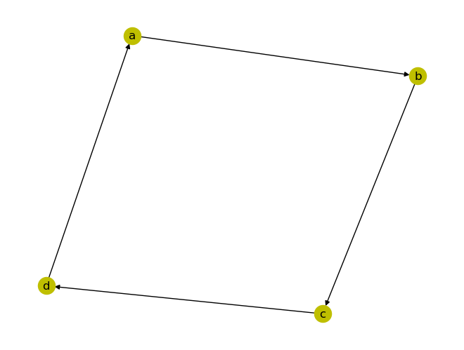

```python
G5a = nx.DiGraph(["ab", "bc", "cd", "da"])
nx.draw(G5a, **opts)
```

And here is one that is weakly connected: there is no path from $c$ to $a$, for example (since $d$ is a "dead end").

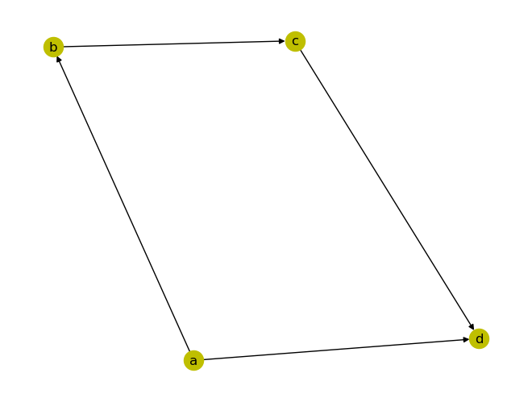

```python
G5b = nx.DiGraph(["ab", "bc", "cd", "ad"])
nx.draw(G5b, **opts)
```

### Construct a digraph

Let $G_5$ be the directed graph on the nodes $0$, $1$, $2$, $3$, $4$ and $5$, with edges $0 \to 1$, $1 \to 2$, $1 \to 3$, $1 \to 4$, $1 \to 5$, $2 \to 4$, $3 \to 2$, $3 \to 4$, $4 \to 3$, $5 \to 0$ and $5 \to 1$.

### Sketch $G_5$

Either by hand, or in `networkx`, draw $G_5$.

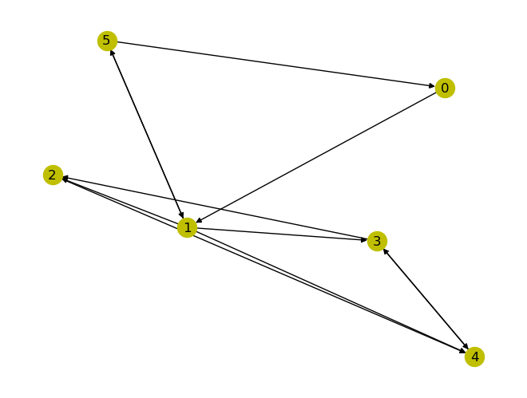

```python
## A drawing of the digraph
G5c = nx.DiGraph(["01", "12", "13", "14", "15",  "24", "32", "34", "43", "50", "51"])
nx.draw(G5c, **opts)
```

### $G_5$ is not strongly connected.

Show that this digraph is *not* strongly connected (i.e., find a pair of nodes between which there is no path).

**Answer:** we can observe that there is no path from, say $2$ to $1$. If we want to do this in `networkx`:

```python
nx.has_path(G5c, '2', '1')
```

```
False
```

### Permuting the adjacency matrix.

Suppose that $A$ is a the adjacency matrix of a digraph. Say there is a permutation matrix, $P$, such that $$ P^T A P = \begin{pmatrix} X & Y \\ O & Z \end{pmatrix}$$ where $X$ and $Z$ are square matrices and $O$ is a zero matrix.

Explain why, if there is such a $P$, the graph is not strongly connected.

Write down the adjacency matrix for $G_5$, and also a permutation matrix $P$ such that $P^T A P$ has the structure described above.

First we show the adjacency matrix for $G_5$, which we denote $A_5$.

```python
A5 = nx.adjacency_matrix(G5c).toarray()
print(A5)
```

```
[[0 1 0 0 0 0]
 [0 0 1 1 1 1]
 [0 0 0 0 1 0]
 [0 0 1 0 1 0]
 [0 0 0 1 0 0]
 [1 1 0 0 0 0]]
```

Then we construct $P$:

```python
P = np.zeros((6,6))
P[0,0]=1 # leave 0 alone
P[1,1]=1 # leave 1 alone
P[2,5]=1 # Move 2 to 5
P[3,3]=1 # leave 3 alone
P[4,4]=1 # leave 4 alone
P[5,2]=1 # Move 5 to 2

print(P)
```

```
[[1. 0. 0. 0. 0. 0.]
 [0. 1. 0. 0. 0. 0.]
 [0. 0. 0. 0. 0. 1.]
 [0. 0. 0. 1. 0. 0.]
 [0. 0. 0. 0. 1. 0.]
 [0. 0. 1. 0. 0. 0.]]
```

Let's check that $P^T A_5 P$ has the correct structure:

```python
print(P.T @ A5 @ P)
```

```
[[0. 1. 0. 0. 0. 0.]
 [0. 0. 1. 1. 1. 1.]
 [1. 1. 0. 0. 0. 0.]
 [0. 0. 0. 0. 1. 1.]
 [0. 0. 0. 1. 0. 0.]
 [0. 0. 0. 0. 1. 0.]]
```